# Introducción a la programación y análisis de datos en R

Día 1 · Bloque 1 — Bienvenida, R y RStudio, primer script

Filip Andras

CIMCYC — Universidad de Granada

9 octubre 2026

## Antes de empezar: descarga el material del curso

1. Entra en github.com/CIMCYC/curso-R-v2026.2
2. Botón verde `Code` → `Download ZIP`
3. Descomprime la carpeta en un sitio que encuentres luego (p. ej. `Documentos/curso_R`)
4. Abre RStudio con doble clic en `exercises/exercises.Rproj`: es el **proyecto** del curso. **Ábrelo siempre así**, no el script suelto
5. Ahí están las diapositivas, los ejercicios y los datos de todo el curso. Lo iremos actualizando: te avisaré cuando haya que volver a descargarlo

# Bienvenida

## ¿Quién soy?

**[Filip Andras](https://cimcyc.ugr.es/informacion/organizacion/filip-andras)**

- Programador y analista de datos ([CIMCYC](https://cimcyc.ugr.es/))
- Psicólogo, Neurocientífico, Investigador
- Experiencia en R aplicado a diferentes ramas en psicología

## Mentimeter ¿Quiénes somos?

Escanea el código QR o entra en:

form.menti.com/s/alfrgndx6rp1

Vamos a conocernos: ¿en qué punto de la carrera investigadora estás?, experiencia previa con R y expectativas.

[figure not shown]

## “Aprender a dibujar”

[figure not shown]

> “…yo pensaba lo importante es la idea, el dibujo no importa, entonces no me preocupé por aprender a dibujar mejor. Hasta un día en que se me ocurrió una idea con un estadio de fútbol lleno de gente y no lo supe dibujar”

> *Joaquín Lavado “Quino”* ([Fuente](https://www.youtube.com/watch?v=quEfn3kDxWQ))

## Muchos mitos que limitan nuestro aprendizaje

**Mitos comunes**

- “Necesito ser bueno/a en matemáticas”
- “La programación es solo para informáticos/as”
- “Es demasiado complicado para mí”
- “Los números y los ordenadores no van conmigo”

[figure not shown]

## Recalibrar algunas creencias que potencian nuestro aprendizaje

**La realidad**

- Solo necesitas tiempo y esfuerzo (tener **paciencia**)
- Es una forma de pensar (mucha **lógica**; *“resolver problemas”*)
- Cuenta con una gran **comunidad** de apoyo (miles de investigadorxs)
- Si puedes usar otro software (e.g., Excel, SPSS), puedes aprender R

[figure not shown]

## Metodología de trabajo

Cada bloque sigue un ciclo de tres fases:

**Idea clave**

No memorizar funciones — aprender a **pensar en R**, saber buscar ayuda y resolver problemas

**Recordar**

Si algo no funciona: **no pasa nada**. Los errores son parte del aprendizaje.

**Fundamental**

Pedir ayuda, preguntar y compartir dudas.

## Planificación del curso

- Curso **práctico** de 4 sesiones (viernes, 9:00 – 14:00)
- **Iniciación**: No se necesita experiencia previa y se abordarán temas básicos
- Al finalizar: **Puedan** importar, transformar, analizar y visualizar datos en R

| Día 1 · 9 oct | Día 2 · 16 oct | Día 3 · 23 oct | Día 4 · 30 oct |
| --- | --- | --- | --- |
| Intro a R y RStudio | Tidyverse: `select()` y `filter()` | Reestructurar datos: `pivot_*()` | Visualización de datos con `ggplot2` |
| R como calculadora, vectores y `NA` | Transformar datos: `mutate()`, `arrange()`, unir tablas | ANOVA de una vía | Reportes reproducibles con Quarto |
| Data frames e importar datos | Resumir por grupos: `group_by()` + `summarise()` | ANOVA de medidas repetidas y mixto | Integración: informe del ensayo |

## Mapa del día 1

Bloque 1  
9:00 – 10:30

Bienvenida

Programar en la era de la IA

¿Qué es R?

RStudio

Instalar y configurar

Ej. 1–4

Bloque 2  
11:00 – 12:30

R como calculadora

Variables

Ej. 5

Tipos de datos

Ej. 6

Vectores

El problema de `NA`

Ej. 7

Indexación

Ej. 8

Bloque 3  
13:00 – 14:00 · 60’

Data frames

Ej. 9–10

Paquetes

Importar datos

Exploración inicial

Ej. 11

# ¿Por qué programar en la era de la IA?

[figure not shown]

¿Qué IA estás usando?

ChatGPT

Gemini

Claude

Perplexity

## Cierto

[figure not shown]

- La IA genera código correcto con frecuencia
- Puede ahorrar tiempo en tareas rutinarias
- Es una herramienta muy útil

## El problema

- ¿Sabes si el resultado es correcto?
- ¿Puedes detectar un error sutil en el análisis?
- ¿Puedes adaptar el código a tus datos?

[figure not shown]

**La IA no sabe lo que tus datos significan — tú sí**

Usar IA sin entender R es como usar una calculadora sin saber matemáticas: obtienes un número, pero no sabes si tiene sentido.

[figure not shown]

## ¿Por qué aprender R si la IA puede escribir el código por mí?

Describir tareas con lenguaje natural

→

conocer los conceptos

Dar órdenes a la IA, escribir prompts e instrucciones

→

saber describir tareas

Corregir y adaptar código

→

entender el código

*Supervisar y evaluar el resultado*

→

tomar decisiones

[The New York Times (2026)](https://www.nytimes.com/es/2026/03/21/espanol/ciencia-y-tecnologia/ia-programacion-trabajo-claude-chatgpt.html)

## Programar + IA = aumentar la capacidad del/a investigador/a

Sin conocimientos de R

No puedes verificar los resultados

(dependes totalmente de la IA). Nota: La IA también se equivoca

Con conocimientos de R

La IA multiplica tu velocidad, tú verificas la calidad

Reproducibilidad

Los revisores/as y coautores/as necesitan entender tu código.

La IA puede producir códigos muy complejos (sin necesidad)

Confianza

En ciencia, el análisis debe ser auditable y transparente

Cómo usaremos IA en este curso

Aprenderemos a programar primero.

Una vez que entiendas la lógica, la IA se convierte en un copiloto — no en el piloto. [Human-AI collaboration (IBM)](https://www.ibm.com/think/topics/human-ai-collaboration)

## Luces y sombras de la IA: 80.508 entrevistas

**APRENDIZAJE**33% lo mencionan como beneficio

3%

30%

**ATROFIA COGNITIVA**17% lo mencionan como perjuicio

8%9%

**MEJOR TOMA DE DECISIONES**22% lo mencionan como beneficio

3%

19%

**FALTA DE FIABILIDAD**37% lo mencionan como perjuicio

29%8%

**AHORRO DE TIEMPO**50% lo mencionan como beneficio

13%37%

**PRODUCTIVIDAD ILUSORIA**18% lo mencionan como perjuicio

17%

1%

lo han vivido lo esperan

[Anthropic (2026). *What 81,000 people want from AI*](https://www.anthropic.com/features/81k-interviews): entrevistas a usuarios/as de Claude.ai en 159 países (diciembre de 2025)

# ¿Qué es R?

## ¿Qué es R?

- R es un conjunto integrado de herramientas de software para la **manipulación** de datos, el **cálculo** y la **representación gráfica** [(Venables & Smith, 2026. R Core Team)](https://cran.r-project.org/doc/manuals/R-intro.pdf)
- Creado en los años 90 por Ross Ihaka y Robert Gentleman en la Universidad de Auckland, Nueva Zelanda.
- Ampliamente usado en investigación científica
- **Gratuito** y de código abierto

## SPSS / JASP / JAMOVI

- Interfaz de menús y clics (muy fácil de ejecutar)
- Resultados difíciles de **reproducir**
- Licencia de pago (SPSS)

[figure not shown]

## SPSS vs. R — en la práctica

**Output de SPSS**

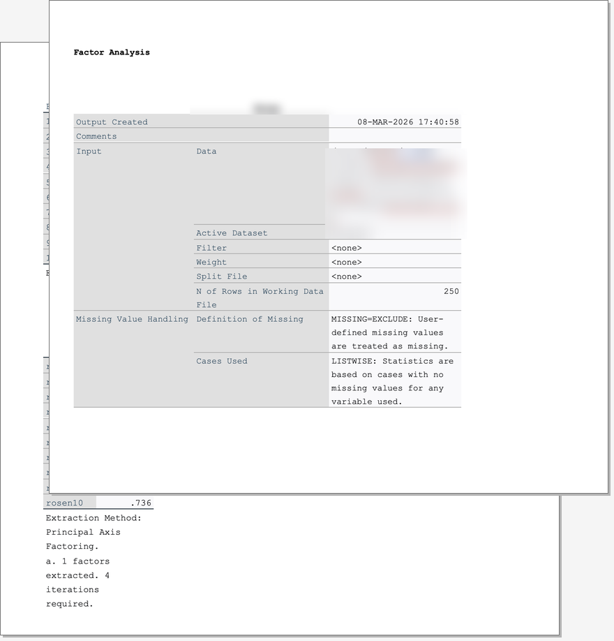

**Informe en R (usando Quarto)**

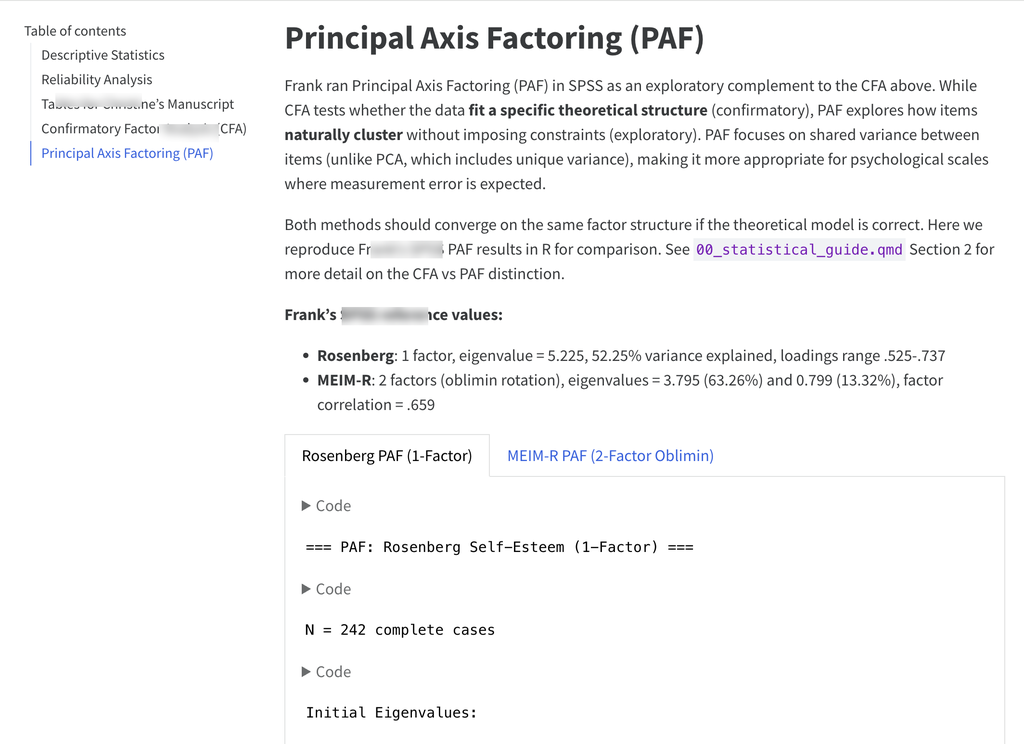

**Revisores/as piden cada vez más un código reproducible**

El output de SPSS es difícil de leer y reproducir. El informe en R+Quarto combina código, resultados y narrativa en un solo documento reproducible.

## ¿Por qué R?

Reproducibilidad

tu análisis es un **script**, no una serie de clics; puedes repetirlo con un clic

Transparencia

software abierto y público

Open science

los scripts de análisis son imprescindibles para las buenas prácticas de ciencia abierta

Flexibilidad

cualquier análisis, cualquier gráfico

Comunidad

miles de tutoriales, foros, paquetes, etc.

Gratis

sin licencias, sin límites

Empleabilidad

habilidad muy demandada en investigación e industria

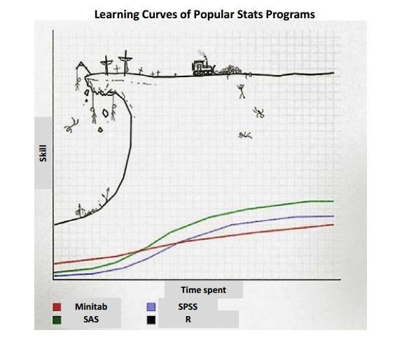

**Nota**

Más trabajo al principio, pero mucha más **flexibilidad** y **reproducibilidad**.

# RStudio

## R y RStudio: ¿cuál es la diferencia?

**R — solo el motor**

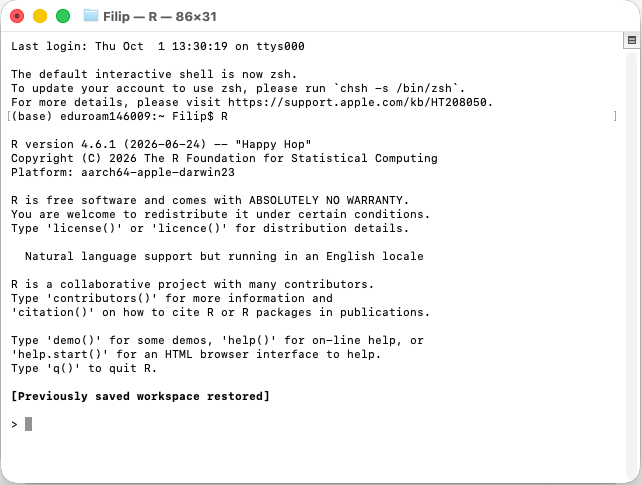

**RStudio — motor + carrocería**

[figure not shown]

Necesitamos **ambos** instalados. RStudio es una interfaz para usar R — R sin RStudio funciona, RStudio sin R no.

## Los cuatro paneles de RStudio

[figure not shown]

## La Consola

[figure not shown]

- Para ejecutar los comandos y mostrar los resultados
- Se pueden ejecutar comandos como líneas individuales o bloques de código (PERO **no se guarda**)
- Pulsando la flecha hacia arriba en la consola se acceden a las últimas líneas de código ejecutadas
- El prompt `>` indica que R está listo para recibir un comando.

**¡Atención al `+`!**

Si ves un `+` en lugar de `>`, R espera que termines un comando incompleto (p. ej., falta un paréntesis). Pulsa **Escape** para cancelar.

## El Editor (Source)

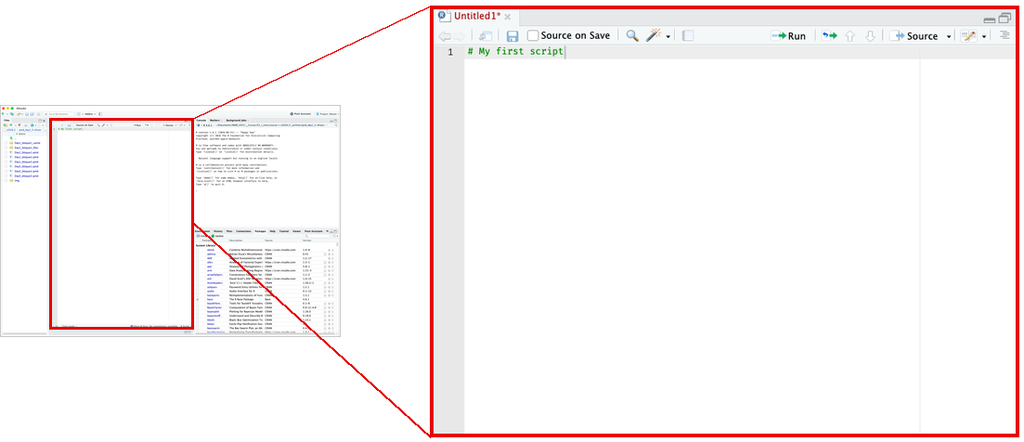

- Editor de texto simple para escribir código
- Permite guardar el código en archivos `.R`
- Puedes usar varias pestañas o scripts a la vez
- Para ejecutar una línea: `Ctrl + Enter` (Windows) / `Cmd + Enter` (Mac)

**Consejo**

Usa **siempre** scripts (.R) en lugar de escribir en la consola. Así puedes reproducir tu trabajo